# hwk_10

Holden Jones

2025-04-28

```r
library(tidyverse)
library(glmmTMB)
library(car)
library(ggeffects)
library(MuMIn)
library(DHARMa)
library(performance)
library(GGally)
stinky <- read_csv('data/stinky.csv')
```

#1.

analyze general spatial and temporal patterns of abundance. plot how abundance varies between sites, seasons, depths

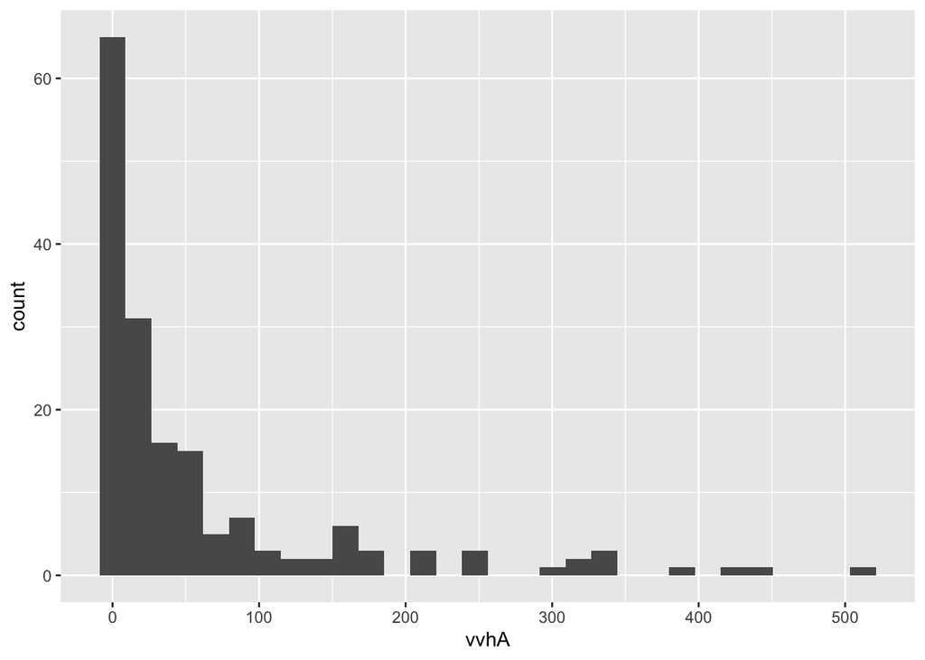

```r
stinky$Site <- as.factor(stinky$Site)

# first, what is dist. of stinky?
stinky %>%
  ggplot(aes(x = vvhA)) +
  geom_histogram()
```

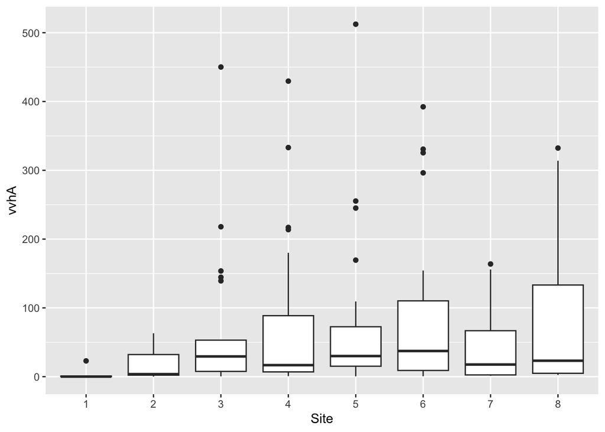

```r
# response var is possible zero-inflated

# lots of variation between sites
stinky %>%
  ggplot(aes(x = Site, y = vvhA)) +
  geom_boxplot()
```

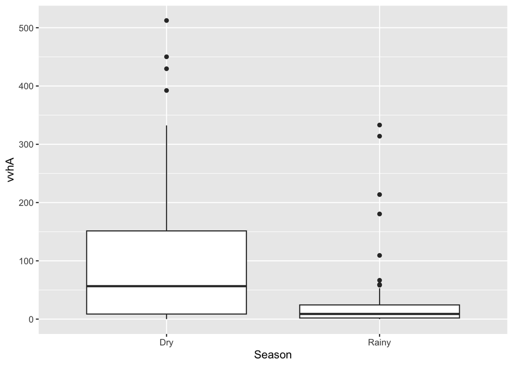

```r
# more stinky during dry season
stinky %>%
  ggplot(aes(x = Season, y = vvhA)) +
  geom_boxplot()
```

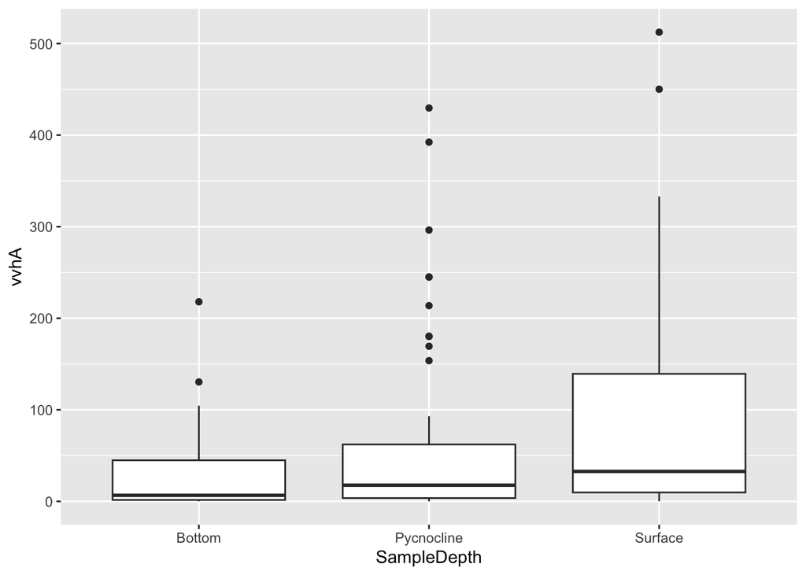

```r
# more stinky at the top of the water column
stinky %>%
  ggplot(aes(x = SampleDepth, y = vvhA)) +
  geom_boxplot()
```

construct appropriate model that tests whether there are effects of these predictors, interactions between them. figure out how to model response variable - likely will need to use zero-inflated - start with Poisson dist - then assess overdispersion - then use neg binom, continue assessing

```r
# Poisson sig dispersion
mod_stinky_pois <- glmmTMB(vvhA ~ Site +
                             Season +
                             SampleDepth +
                             Site*Season +
                             Site*SampleDepth +
                             Season*SampleDepth,
                          data = stinky,
                          family = poisson)
summary(mod_stinky_pois)
```

```
##  Family: poisson  ( log )
## Formula:
## vvhA ~ Site + Season + SampleDepth + Site * Season + Site * SampleDepth +
##     Season * SampleDepth
## Data: stinky
##
##       AIC       BIC    logLik -2*log(L)  df.resid
##    9261.5    9368.4   -4596.8    9193.5       137
##
##
## Conditional model:
##                                   Estimate Std. Error z value Pr(>|z|)
## (Intercept)                       -2.96751    0.98182  -3.022 0.002507 **
## Site2                              4.55975    1.01080   4.511 6.45e-06 ***
## Site3                              7.38739    0.98326   7.513 5.77e-14 ***
## Site4                              6.17131    0.98354   6.275 3.51e-10 ***
## Site5                              6.67345    0.98362   6.785 1.16e-11 ***
## Site6                              7.45006    0.98283   7.580 3.45e-14 ***
## Site7                              7.30843    0.98409   7.427 1.11e-13 ***
## Site8                              6.48379    0.98351   6.593 4.32e-11 ***
## SeasonRainy                        2.52762    0.58265   4.338 1.44e-05 ***
## SampleDepthPycnocline             -1.01935    1.78861  -0.570 0.568737
## SampleDepthSurface                 3.03628    0.85789   3.539 0.000401 ***
## Site2:SeasonRainy                 -3.23680    0.58887  -5.497 3.87e-08 ***
## Site3:SeasonRainy                 -4.31311    0.58292  -7.399 1.37e-13 ***
## Site4:SeasonRainy                 -3.06408    0.58020  -5.281 1.28e-07 ***
## Site5:SeasonRainy                 -3.94019    0.58134  -6.778 1.22e-11 ***
## Site6:SeasonRainy                 -4.67165    0.58265  -8.018 1.08e-15 ***
## Site7:SeasonRainy                 -4.45470    0.58684  -7.591 3.17e-14 ***
## Site8:SeasonRainy                 -3.15486    0.58023  -5.437 5.41e-08 ***
## Site2:SampleDepthPycnocline        2.53319    1.80629   1.402 0.160787
## Site3:SampleDepthPycnocline        0.87176    1.79012   0.487 0.626272
## Site4:SampleDepthPycnocline        2.90840    1.78944   1.625 0.104096
## Site5:SampleDepthPycnocline        2.12447    1.78987   1.187 0.235251
## Site6:SampleDepthPycnocline        1.79438    1.78939   1.003 0.315961
## Site7:SampleDepthPycnocline        0.73310    1.79099   0.409 0.682300
## Site8:SampleDepthPycnocline        2.03256    1.78976   1.136 0.256097
## Site2:SampleDepthSurface          -0.82915    0.89204  -0.930 0.352627
## Site3:SampleDepthSurface          -2.23584    0.85999  -2.600 0.009327 **
## Site4:SampleDepthSurface          -1.34058    0.85989  -1.559 0.118994
## Site5:SampleDepthSurface          -1.36766    0.86021  -1.590 0.111855
## Site6:SampleDepthSurface          -2.13514    0.85946  -2.484 0.012981 *
## Site7:SampleDepthSurface          -2.63492    0.86146  -3.059 0.002223 **
## Site8:SampleDepthSurface          -1.22381    0.85995  -1.423 0.154703
## SeasonRainy:SampleDepthPycnocline -0.24761    0.08440  -2.934 0.003350 **
## SeasonRainy:SampleDepthSurface    -0.14002    0.07919  -1.768 0.077040 .
## ---
## Signif. codes:  0 '***' 0.001 '**' 0.01 '*' 0.05 '.' 0.1 ' ' 1
```

```r
Anova(mod_stinky_pois) # all have sig effect
```

```
## Analysis of Deviance Table (Type II Wald chisquare tests)
##
## Response: vvhA
##                        Chisq Df Pr(>Chisq)
## Site               1146.7542  7  < 2.2e-16 ***
## Season             2612.8758  1  < 2.2e-16 ***
## SampleDepth        1558.2388  2  < 2.2e-16 ***
## Site:Season         654.9131  7  < 2.2e-16 ***
## Site:SampleDepth    706.4331 14  < 2.2e-16 ***
## Season:SampleDepth    9.2362  2   0.009871 **
## ---
## Signif. codes:  0 '***' 0.001 '**' 0.01 '*' 0.05 '.' 0.1 ' ' 1
```

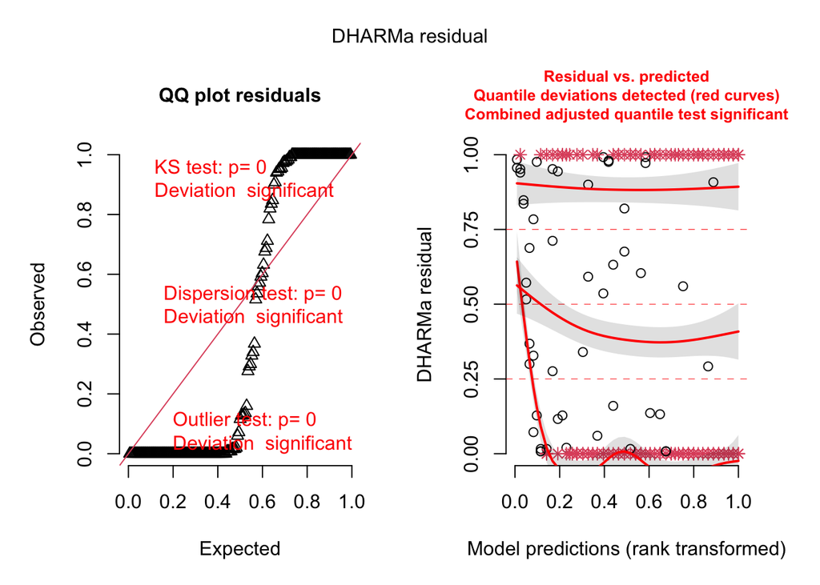

```r
sim_res_model <- simulateResiduals(fittedModel = mod_stinky_pois)
plot(sim_res_model) # significant deviation suggesting overdispersion
```

```r
check_overdispersion(mod_stinky_pois) # overdispersion detected
```

```
## # Overdispersion test
##
##        dispersion ratio =   64.455
##   Pearson's Chi-Squared = 8830.355
##                 p-value =  < 0.001
```

```
## Overdispersion detected.
```

```
## Some of the focal terms are of type `character`. This may lead to
##   unexpected results. It is recommended to convert these variables to
##   factors before fitting the model.
##   The following variables are of type character: `Season`, `SampleDepth`
```

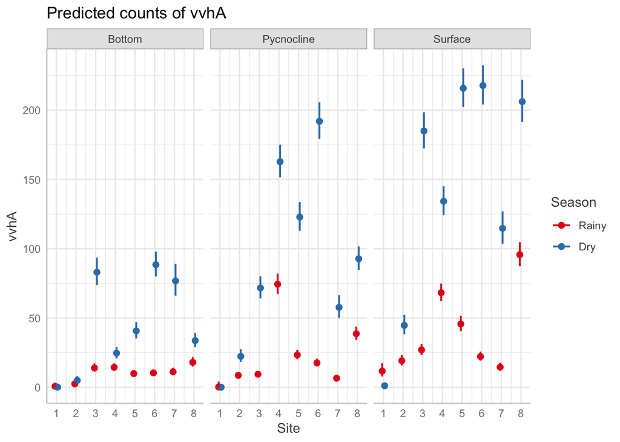

```r
plot(ggpredict(mod_stinky_pois, terms = c("Site", "Season", "SampleDepth")))
```

Neg binomial - b/c Poisson sig overdispersion - neg binom looks good! no need for zero-inflation!

```r
mod_stinky_nb <- glmmTMB(vvhA ~ Site +
                             Season +
                             SampleDepth +
                             Site*Season +
                             Site*SampleDepth +
                             Season*SampleDepth,
                          data = stinky,
                          family = nbinom2)
summary(mod_stinky_nb)
```

```
##  Family: nbinom2  ( log )
## Formula:
## vvhA ~ Site + Season + SampleDepth + Site * Season + Site * SampleDepth +
##     Season * SampleDepth
## Data: stinky
##
##       AIC       BIC    logLik -2*log(L)  df.resid
##    1569.4    1679.3    -749.7    1499.4       136
##
##
## Dispersion parameter for nbinom2 family (): 0.892
##
## Conditional model:
##                                   Estimate Std. Error z value Pr(>|z|)
## (Intercept)                       -1.92579    1.14738  -1.678 0.093264 .
## Site2                              3.62395    1.28663   2.817 0.004853 **
## Site3                              6.03161    1.24056   4.862 1.16e-06 ***
## Site4                              5.20257    1.20789   4.307 1.65e-05 ***
## Site5                              5.79190    1.22724   4.719 2.36e-06 ***
## Site6                              7.12957    1.26066   5.655 1.55e-08 ***
## Site7                              6.43280    1.27897   5.030 4.91e-07 ***
## Site8                              5.50359    1.22371   4.497 6.88e-06 ***
## SeasonRainy                        1.60921    1.03458   1.555 0.119847
## SampleDepthPycnocline             -1.50068    2.03410  -0.738 0.460660
## SampleDepthSurface                 2.21840    1.19036   1.864 0.062372 .
## Site2:SeasonRainy                 -2.67813    1.10994  -2.413 0.015828 *
## Site3:SeasonRainy                 -3.82315    1.10997  -3.444 0.000572 ***
## Site4:SeasonRainy                 -2.66864    1.07901  -2.473 0.013390 *
## Site5:SeasonRainy                 -3.15077    1.08223  -2.911 0.003598 **
## Site6:SeasonRainy                 -3.96511    1.09001  -3.638 0.000275 ***
## Site7:SeasonRainy                 -3.82895    1.10876  -3.453 0.000554 ***
## Site8:SeasonRainy                 -2.45475    1.08899  -2.254 0.024187 *
## Site2:SampleDepthPycnocline        2.92091    2.12036   1.378 0.168341
## Site3:SampleDepthPycnocline        1.96927    2.12920   0.925 0.355023
## Site4:SampleDepthPycnocline        3.35100    2.08030   1.611 0.107217
## Site5:SampleDepthPycnocline        2.40649    2.08385   1.155 0.248162
## Site6:SampleDepthPycnocline        1.36155    2.09822   0.649 0.516396
## Site7:SampleDepthPycnocline        0.94923    2.11345   0.449 0.653333
## Site8:SampleDepthPycnocline        2.44980    2.08842   1.173 0.240779
## Site2:SampleDepthSurface          -0.09380    1.34815  -0.070 0.944531
## Site3:SampleDepthSurface          -1.04748    1.34221  -0.780 0.435151
## Site4:SampleDepthSurface          -0.39966    1.27540  -0.313 0.754008
## Site5:SampleDepthSurface          -0.85622    1.28509  -0.666 0.505235
## Site6:SampleDepthSurface          -2.29492    1.29679  -1.770 0.076779 .
## Site7:SampleDepthSurface          -1.96687    1.32659  -1.483 0.138167
## Site8:SampleDepthSurface          -0.55149    1.29791  -0.425 0.670904
## SeasonRainy:SampleDepthPycnocline  0.09196    0.45839   0.201 0.841007
## SeasonRainy:SampleDepthSurface     0.19379    0.45423   0.427 0.669655
## ---
## Signif. codes:  0 '***' 0.001 '**' 0.01 '*' 0.05 '.' 0.1 ' ' 1
```

```r
Anova(mod_stinky_nb) # Site, Season, SampleDepth, Site*Season sig effects
```

```
## Analysis of Deviance Table (Type II Wald chisquare tests)
##
## Response: vvhA
##                     Chisq Df Pr(>Chisq)
## Site               75.222  7  1.293e-13 ***
## Season             60.767  1  6.425e-15 ***
## SampleDepth        39.306  2  2.917e-09 ***
## Site:Season        21.054  7   0.003691 **
## Site:SampleDepth   20.012 14   0.129777
## Season:SampleDepth  0.186  2   0.911214
## ---
## Signif. codes:  0 '***' 0.001 '**' 0.01 '*' 0.05 '.' 0.1 ' ' 1
```

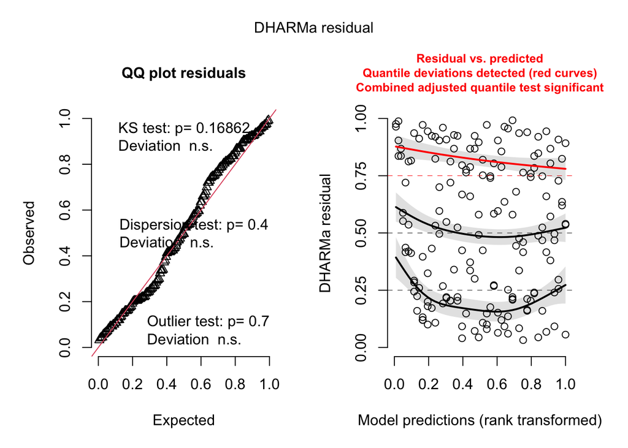

```r
sim_res_model <- simulateResiduals(fittedModel = mod_stinky_nb)
plot(sim_res_model) # looks like negbinom fits well! move forward with this
```

```r
check_overdispersion(mod_stinky_nb) # no overdispersion detected
```

```
## # Overdispersion test
##
##  dispersion ratio = 0.684
##           p-value =   0.4
```

```
## No overdispersion detected.
```

```
## Some of the focal terms are of type `character`. This may lead to
##   unexpected results. It is recommended to convert these variables to
##   factors before fitting the model.
##   The following variables are of type character: `Season`, `SampleDepth`
```

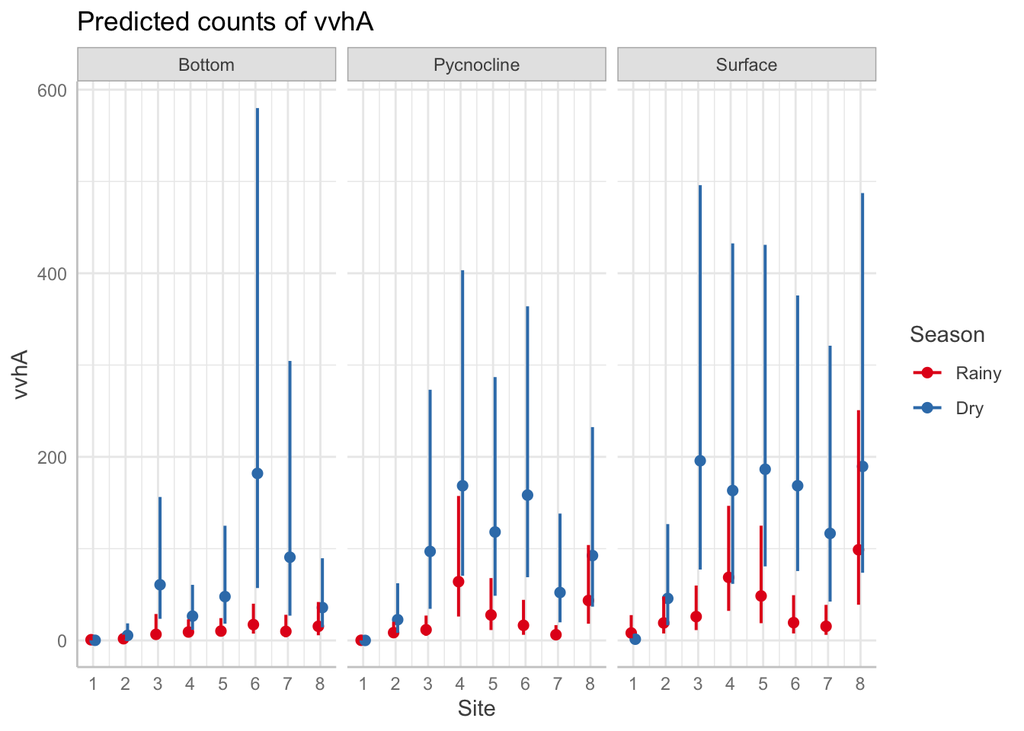

```r
plot(ggpredict(mod_stinky_nb, terms = c("Site", "Season", "SampleDepth")))
```

what are magnitudes of modeled effects? - season has a large significant effect, lots more stinky in dry season - site appears to have a large significant effect, sites 6, 7 have much more stinky - depth appears to have an intermediate significant effect, more stinky at surface - site*season appears to have small significant effect, see some variation in season across sites, but for most sites, rainy season is lower

what are interpretations of results so far? - it seems that season is the most important driver of hhvA, with significantly more stinky in the dry season. there’s also a lot of variation across the 8 sampling sites, with 6 and 7 appearing to be especially high, even at the lower sampling depths, which have lower hhvA than the surface level.

#2.

authors only used Rainfall_5Day, AirTemp, 02Conc, Salinity, WaterTemp, Turbidity, Chlorophyll, NOx, Silicate, POC, TotalP, Tyrosine.like, HIX, VisibleHumic. likely b/c lots of correlaton b/ween variables, these ones are supposed to be important

scatterplot concentration vs. predictors to consider which predictors should be transformed for use in linear model / generalized linear model. recall transformation not about normality (predictors not assumed to follow any dist). rather, transformation useful for achieving linear relationships, and avoiding extreme values that have outsized leverage on modeled relationship

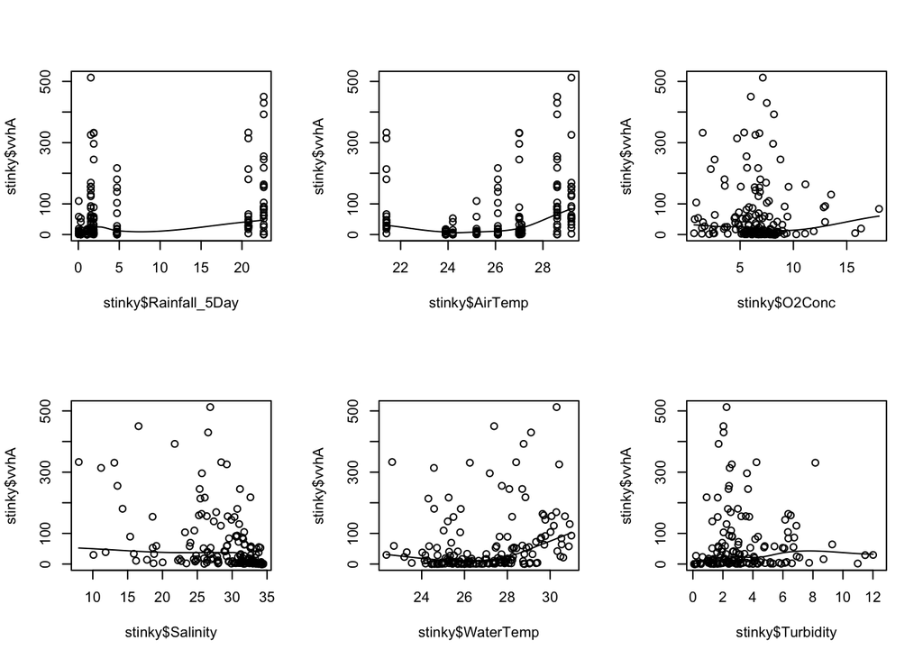

```r
par(mfrow = c(2, 3))
scatter.smooth(stinky$Rainfall_5Day, stinky$vvhA)
scatter.smooth(stinky$AirTemp, stinky$vvhA)
scatter.smooth(stinky$O2Conc, stinky$vvhA)
scatter.smooth(stinky$Salinity, stinky$vvhA)
scatter.smooth(stinky$WaterTemp, stinky$vvhA)
scatter.smooth(stinky$Turbidity, stinky$vvhA)
```

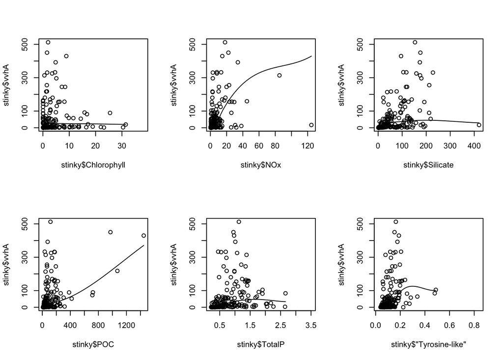

```r
scatter.smooth(stinky$Chlorophyll, stinky$vvhA)
scatter.smooth(stinky$NOx, stinky$vvhA) # outsized leverage
scatter.smooth(stinky$Silicate, stinky$vvhA) # outsized leverage
scatter.smooth(stinky$POC, stinky$vvhA) # outsized leverage
scatter.smooth(stinky$TotalP, stinky$vvhA)
scatter.smooth(stinky$'Tyrosine-like', stinky$vvhA) # outsized leverage
```

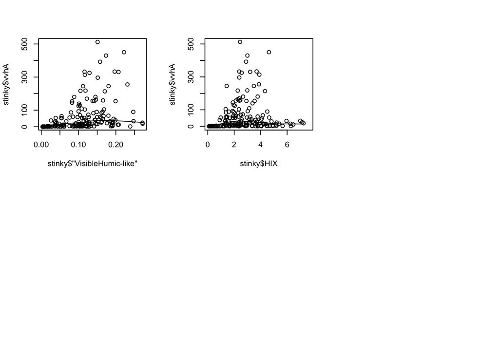

```r
scatter.smooth(stinky$'VisibleHumic-like', stinky$vvhA)
scatter.smooth(stinky$HIX, stinky$vvhA)

# log transform following predictors due to outsized leverage of outlier points
stinky$log_NOx <- log(stinky$NOx)
stinky$log_Silicate <- log(stinky$Silicate)
stinky$log_POC <- log(stinky$POC)
stinky$'log_Tyrosine-like' <- log(stinky$'Tyrosine-like')
```

make single predictor models for each of 14 predictors above note in order to compare models by AIC each model needs to use same set of samples (rows) - means should remove any rows that include NAs for any of 14 predictors, or for response variable, before fitting any models

prepare df for modeling predictors

```r
# first need to remove any rows that include NAs - simplify df as well
variables <- c('vvhA', 'Rainfall_5Day', 'AirTemp', 'O2Conc', 'Salinity', 'WaterTemp',
               'Turbidity', 'Chlorophyll', 'TotalP', 'log_NOx', 'log_Silicate',
               'log_POC', 'log_Tyrosine-like', 'VisibleHumic-like', 'HIX')

df <- stinky %>%
  select(variables)
# this is a super annoying way to do this, but I'm on a plane with no internet rn
df <- df %>%
  filter(!is.na(vvhA)) %>%
  filter(!is.na(Rainfall_5Day)) %>%
  filter(!is.na(AirTemp)) %>%
  filter(!is.na(O2Conc)) %>%
  filter(!is.na(Salinity)) %>%
  filter(!is.na(WaterTemp)) %>%
  filter(!is.na(Turbidity)) %>%
  filter(!is.na(Chlorophyll)) %>%
  filter(!is.na(TotalP)) %>%
  filter(!is.na(log_NOx)) %>%
  filter(!is.na(log_Silicate)) %>%
  filter(!is.na(log_POC)) %>%
  filter(!is.na('log_Tyrosine-like')) %>%
  filter(!is.na('VisibleHumic-like')) %>%
  filter(!is.na(HIX))

# annoying naming of variables, should have fixed earlier
df$log_Tyrosine <- df$'log_Tyrosine-like'
df$VisibleHumic <- df$'VisibleHumic-like'
```

14 models for 14 predictors

```r
# rainfall sig pos
mod_Rainfall_5Day <- lm(vvhA ~ Rainfall_5Day, df)
summary(mod_Rainfall_5Day)
```

```
##
## Call:
## lm(formula = vvhA ~ Rainfall_5Day, data = df)
##
## Residuals:
##     Min      1Q  Median      3Q     Max
## -128.87  -39.22  -30.79   11.38  470.90
##
## Coefficients:
##               Estimate Std. Error t value Pr(>|t|)
## (Intercept)     34.301      8.890   3.859 0.000168 ***
## Rainfall_5Day    4.721      0.913   5.171 7.24e-07 ***
## ---
## Signif. codes:  0 '***' 0.001 '**' 0.01 '*' 0.05 '.' 0.1 ' ' 1
##
## Residual standard error: 91.13 on 152 degrees of freedom
## Multiple R-squared:  0.1496, Adjusted R-squared:  0.144
## F-statistic: 26.74 on 1 and 152 DF,  p-value: 7.236e-07
```

```r
# air temp sig pos
mod_AirTemp <- lm(vvhA ~ AirTemp, df)
summary(mod_AirTemp)
```

```
##
## Call:
## lm(formula = vvhA ~ AirTemp, data = df)
##
## Residuals:
##     Min      1Q  Median      3Q     Max
## -110.75  -53.68  -26.29   12.73  399.28
##
## Coefficients:
##             Estimate Std. Error t value Pr(>|t|)
## (Intercept)  -380.70      88.43  -4.305 2.98e-05 ***
## AirTemp        16.91       3.38   5.003 1.54e-06 ***
## ---
## Signif. codes:  0 '***' 0.001 '**' 0.01 '*' 0.05 '.' 0.1 ' ' 1
##
## Residual standard error: 91.56 on 152 degrees of freedom
## Multiple R-squared:  0.1414, Adjusted R-squared:  0.1358
## F-statistic: 25.03 on 1 and 152 DF,  p-value: 1.539e-06
```

```r
# O2Conc no effect
mod_O2Conc <- lm(vvhA ~ O2Conc, df)
summary(mod_O2Conc)
```

```
##
## Call:
## lm(formula = vvhA ~ O2Conc, data = df)
##
## Residuals:
##    Min     1Q Median     3Q    Max
## -62.00 -57.13 -45.08   2.38 452.50
##
## Coefficients:
##             Estimate Std. Error t value Pr(>|t|)
## (Intercept)  64.6374    20.8768   3.096  0.00234 **
## O2Conc       -0.6655     2.9002  -0.229  0.81883
## ---
## Signif. codes:  0 '***' 0.001 '**' 0.01 '*' 0.05 '.' 0.1 ' ' 1
##
## Residual standard error: 98.8 on 152 degrees of freedom
## Multiple R-squared:  0.0003462,  Adjusted R-squared:  -0.00623
## F-statistic: 0.05265 on 1 and 152 DF,  p-value: 0.8188
```

```r
# Salinity sig neg
mod_Salinity <- lm(vvhA ~ Salinity, df)
summary(mod_Salinity)
```

```
##
## Call:
## lm(formula = vvhA ~ Salinity, data = df)
##
## Residuals:
##     Min      1Q  Median      3Q     Max
## -156.54  -41.89  -23.28   22.20  439.29
##
## Coefficients:
##             Estimate Std. Error t value Pr(>|t|)
## (Intercept)  254.452     37.935   6.708 3.67e-10 ***
## Salinity      -6.754      1.294  -5.219 5.82e-07 ***
## ---
## Signif. codes:  0 '***' 0.001 '**' 0.01 '*' 0.05 '.' 0.1 ' ' 1
##
## Residual standard error: 91 on 152 degrees of freedom
## Multiple R-squared:  0.152,  Adjusted R-squared:  0.1464
## F-statistic: 27.24 on 1 and 152 DF,  p-value: 5.817e-07
```

```r
# WaterTemp sig pos
mod_WaterTemp <- lm(vvhA ~ WaterTemp, df)
summary(mod_WaterTemp)
```

```
##
## Call:
## lm(formula = vvhA ~ WaterTemp, data = df)
##
## Residuals:
##    Min     1Q Median     3Q    Max
## -96.91 -52.74 -28.95   7.50 399.19
##
## Coefficients:
##             Estimate Std. Error t value Pr(>|t|)
## (Intercept) -373.639    103.624  -3.606 0.000422 ***
## WaterTemp     16.067      3.827   4.198 4.57e-05 ***
## ---
## Signif. codes:  0 '***' 0.001 '**' 0.01 '*' 0.05 '.' 0.1 ' ' 1
##
## Residual standard error: 93.54 on 152 degrees of freedom
## Multiple R-squared:  0.1039, Adjusted R-squared:  0.098
## F-statistic: 17.62 on 1 and 152 DF,  p-value: 4.569e-05
```

```r
# Turbidity no effect
mod_Turbidity <- lm(vvhA ~ Turbidity, df)
summary(mod_Turbidity)
```

```
##
## Call:
## lm(formula = vvhA ~ Turbidity, data = df)
##
## Residuals:
##    Min     1Q Median     3Q    Max
## -72.06 -54.87 -44.82   2.62 453.84
##
## Coefficients:
##             Estimate Std. Error t value Pr(>|t|)
## (Intercept)   54.678     13.758   3.974 0.000109 ***
## Turbidity      1.728      3.506   0.493 0.622877
## ---
## Signif. codes:  0 '***' 0.001 '**' 0.01 '*' 0.05 '.' 0.1 ' ' 1
##
## Residual standard error: 98.74 on 152 degrees of freedom
## Multiple R-squared:  0.001595,   Adjusted R-squared:  -0.004973
## F-statistic: 0.2428 on 1 and 152 DF,  p-value: 0.6229
```

```r
# Chlorophyll no effect
mod_Chlorophyll <- lm(vvhA ~ Chlorophyll, df)
summary(mod_Chlorophyll)
```

```
##
## Call:
## lm(formula = vvhA ~ Chlorophyll, data = df)
##
## Residuals:
##    Min     1Q Median     3Q    Max
## -62.90 -57.72 -43.89   2.24 450.66
##
## Coefficients:
##             Estimate Std. Error t value Pr(>|t|)
## (Intercept)  63.0507     9.8682   6.389 1.93e-09 ***
## Chlorophyll  -0.6648     1.3656  -0.487    0.627
## ---
## Signif. codes:  0 '***' 0.001 '**' 0.01 '*' 0.05 '.' 0.1 ' ' 1
##
## Residual standard error: 98.74 on 152 degrees of freedom
## Multiple R-squared:  0.001557,   Adjusted R-squared:  -0.005012
## F-statistic: 0.237 on 1 and 152 DF,  p-value: 0.6271
```

```r
# TotalP sig pos
mod_TotalP <- lm(vvhA ~ TotalP, df)
summary(mod_TotalP)
```

```
##
## Call:
## lm(formula = vvhA ~ TotalP, data = df)
##
## Residuals:
##     Min      1Q  Median      3Q     Max
## -123.64  -44.58  -37.17    0.49  442.64
##
## Coefficients:
##             Estimate Std. Error t value Pr(>|t|)
## (Intercept)    27.46      15.48   1.774   0.0781 .
## TotalP         37.50      15.31   2.449   0.0154 *
## ---
## Signif. codes:  0 '***' 0.001 '**' 0.01 '*' 0.05 '.' 0.1 ' ' 1
##
## Residual standard error: 96.92 on 152 degrees of freedom
## Multiple R-squared:  0.03797,    Adjusted R-squared:  0.03164
## F-statistic:     6 on 1 and 152 DF,  p-value: 0.01545
```

```r
# log_NOx sig pos
mod_log_NOx <- lm(vvhA ~ log_NOx, df)
summary(mod_log_NOx)
```

```
##
## Call:
## lm(formula = vvhA ~ log_NOx, data = df)
##
## Residuals:
##     Min      1Q  Median      3Q     Max
## -169.28  -45.91  -15.86   19.53  393.40
##
## Coefficients:
##             Estimate Std. Error t value Pr(>|t|)
## (Intercept)   18.888      9.510   1.986   0.0488 *
## log_NOx       34.617      5.347   6.474 1.24e-09 ***
## ---
## Signif. codes:  0 '***' 0.001 '**' 0.01 '*' 0.05 '.' 0.1 ' ' 1
##
## Residual standard error: 87.49 on 152 degrees of freedom
## Multiple R-squared:  0.2161, Adjusted R-squared:  0.211
## F-statistic: 41.91 on 1 and 152 DF,  p-value: 1.244e-09
```

```r
# log_Silicate sig pos
mod_log_Silicate <- lm(vvhA ~ log_Silicate, df)
summary(mod_log_Silicate)
```

```
##
## Call:
## lm(formula = vvhA ~ log_Silicate, data = df)
##
## Residuals:
##     Min      1Q  Median      3Q     Max
## -124.70  -52.54  -22.52   24.79  404.89
##
## Coefficients:
##              Estimate Std. Error t value Pr(>|t|)
## (Intercept)   -61.454     20.633  -2.978  0.00337 **
## log_Silicate   33.571      5.346   6.279 3.39e-09 ***
## ---
## Signif. codes:  0 '***' 0.001 '**' 0.01 '*' 0.05 '.' 0.1 ' ' 1
##
## Residual standard error: 88.05 on 152 degrees of freedom
## Multiple R-squared:  0.206,  Adjusted R-squared:  0.2008
## F-statistic: 39.43 on 1 and 152 DF,  p-value: 3.39e-09
```

```r
# log_POC sig pos
mod_log_POC <- lm(vvhA ~ log_POC, df)
summary(mod_log_POC)
```

```
##
## Call:
## lm(formula = vvhA ~ log_POC, data = df)
##
## Residuals:
##     Min      1Q  Median      3Q     Max
## -120.47  -53.15  -20.15   16.02  431.39
##
## Coefficients:
##             Estimate Std. Error t value Pr(>|t|)
## (Intercept) -127.939     33.231   -3.85 0.000174 ***
## log_POC       43.897      7.569    5.80 3.72e-08 ***
## ---
## Signif. codes:  0 '***' 0.001 '**' 0.01 '*' 0.05 '.' 0.1 ' ' 1
##
## Residual standard error: 89.42 on 152 degrees of freedom
## Multiple R-squared:  0.1812, Adjusted R-squared:  0.1758
## F-statistic: 33.64 on 1 and 152 DF,  p-value: 3.72e-08
```

```r
# log_Tyrosine sig pos
mod_log_Tyrosine <- lm(vvhA ~ log_Tyrosine, df)
summary(mod_log_Tyrosine)
```

```
##
## Call:
## lm(formula = vvhA ~ log_Tyrosine, data = df)
##
## Residuals:
##     Min      1Q  Median      3Q     Max
## -121.29  -50.04  -22.75    8.70  415.64
##
## Coefficients:
##              Estimate Std. Error t value Pr(>|t|)
## (Intercept)    239.62      35.72   6.708 3.65e-10 ***
## log_Tyrosine    79.07      15.41   5.132 8.62e-07 ***
## ---
## Signif. codes:  0 '***' 0.001 '**' 0.01 '*' 0.05 '.' 0.1 ' ' 1
##
## Residual standard error: 91.23 on 152 degrees of freedom
## Multiple R-squared:  0.1477, Adjusted R-squared:  0.1421
## F-statistic: 26.34 on 1 and 152 DF,  p-value: 8.619e-07
```

```r
# VisibleHumic sig pos
mod_VisibleHumic <- lm(vvhA ~ VisibleHumic, df)
summary(mod_VisibleHumic)
```

```
##
## Call:
## lm(formula = vvhA ~ VisibleHumic, data = df)
##
## Residuals:
##     Min      1Q  Median      3Q     Max
## -137.48  -52.30  -18.75    9.50  426.60
##
## Coefficients:
##              Estimate Std. Error t value Pr(>|t|)
## (Intercept)    -1.836     15.068  -0.122    0.903
## VisibleHumic  580.300    122.587   4.734 5.01e-06 ***
## ---
## Signif. codes:  0 '***' 0.001 '**' 0.01 '*' 0.05 '.' 0.1 ' ' 1
##
## Residual standard error: 92.25 on 152 degrees of freedom
## Multiple R-squared:  0.1285, Adjusted R-squared:  0.1228
## F-statistic: 22.41 on 1 and 152 DF,  p-value: 5.005e-06
```

```r
# HIX no effect
mod_HIX <- lm(vvhA ~ HIX, df)
summary(mod_HIX)
```

```
##
## Call:
## lm(formula = vvhA ~ HIX, data = df)
##
## Residuals:
##    Min     1Q Median     3Q    Max
## -69.65 -54.40 -47.40   5.87 453.04
##
## Coefficients:
##             Estimate Std. Error t value Pr(>|t|)
## (Intercept)   51.867     16.397   3.163  0.00188 **
## HIX            3.069      5.275   0.582  0.56155
## ---
## Signif. codes:  0 '***' 0.001 '**' 0.01 '*' 0.05 '.' 0.1 ' ' 1
##
## Residual standard error: 98.71 on 152 degrees of freedom
## Multiple R-squared:  0.002222,   Adjusted R-squared:  -0.004342
## F-statistic: 0.3385 on 1 and 152 DF,  p-value: 0.5615
```

which predictors, on their own, best explain concentration? - There are many predictors which on their own have a significant effect on vvhA. These are; Rainfall_5Day, AirTemp, Salinity, WaterTemp, TotalP, log_NOx,  
log_Silicate, log_POC, log_Tyrosine, VisibleHumic

if make AIC table of 14 models, what do Akaike weights look like? - the model with log_NOx is the best performing (weight of .7, 2 delta better than next best). The model with Silicate is next best.

make AIC weights

```r
models <- list(mod_Rainfall_5Day, mod_AirTemp, mod_O2Conc, mod_Salinity,
               mod_WaterTemp, mod_Turbidity, mod_Chlorophyll, mod_TotalP,
               mod_log_NOx, mod_log_Silicate, mod_log_POC, mod_log_Tyrosine,
               mod_VisibleHumic, mod_HIX)

model_selection <- model.sel(models)
print(model_selection)
```

```
## Model selection table
##       (Int) Rnf_5Dy   ArT     O2C    Sln   WtT   Trb     Chl  TtP log_NOx
## 9    18.890                                                         34.62
## 10  -61.450
## 11 -127.900
## 4   254.500                       -6.754
## 1    34.300   4.721
## 12  239.600
## 2  -380.700         16.91
## 13   -1.836
## 5  -373.600                              16.07
## 8    27.460                                                  37.5
## 14   51.870
## 6    54.680                                    1.728
## 7    63.050                                          -0.6648
```

[output cut: 17 more lines]

what does this mean? - this means that our model selection process identified log_NOx as the most important driver of vvhA for the variables assessed. It is also plausible that Silicate may be the best model as the delta between AICs was less than 2, although just barely!

what is downside of using single-predictor models in this context? - we’re making a lot of assumptions. We’re assuming that none of these predictor variables are interacting with each other. We’ve tried to address collinearity, but we can’t assess interaction with this setup. We also are assuming that these variables are independent, and that we are able to identify the best model using AIC. Probably most importantly, we’re assuming that the relationship between the response and predictor variables is simple enough that it can be modled with just one predictor.

now, make one big model that contains all 14 predictors

```r
big_model <- lm(vvhA ~ Rainfall_5Day + AirTemp + O2Conc + Salinity +
                 WaterTemp + Turbidity + Chlorophyll + TotalP + log_NOx +
                 log_Silicate + log_POC + log_Tyrosine + VisibleHumic + HIX,
                data = df, na.action = na.pass)
summary(big_model)
```

```
##
## Call:
## lm(formula = vvhA ~ Rainfall_5Day + AirTemp + O2Conc + Salinity +
##     WaterTemp + Turbidity + Chlorophyll + TotalP + log_NOx +
##     log_Silicate + log_POC + log_Tyrosine + VisibleHumic + HIX,
##     data = df, na.action = na.pass)
##
## Residuals:
##     Min      1Q  Median      3Q     Max
## -197.63  -33.91   -6.81   21.10  345.55
##
## Coefficients:
##                Estimate Std. Error t value Pr(>|t|)
## (Intercept)   -207.4890   140.0226  -1.482  0.14065
## Rainfall_5Day    1.6753     0.9894   1.693  0.09267 .
## AirTemp          9.1368     5.6284   1.623  0.10678
## O2Conc          -2.3376     2.4028  -0.973  0.33230
## Salinity        -3.7222     2.1431  -1.737  0.08463 .
## WaterTemp       -2.1975     7.7740  -0.283  0.77785
## Turbidity       -1.9888     2.9121  -0.683  0.49577
## Chlorophyll     -0.7459     1.5006  -0.497  0.61991
## TotalP         -28.4919    17.4358  -1.634  0.10450
## log_NOx         32.4375    10.0677   3.222  0.00159 **
## log_Silicate    -2.7157    10.5718  -0.257  0.79765
## log_POC         31.4810    10.2334   3.076  0.00252 **
## log_Tyrosine   -53.8268    29.1512  -1.846  0.06695 .
## VisibleHumic   786.7522   349.0574   2.254  0.02577 *
## HIX            -49.0724    12.8889  -3.807  0.00021 ***
## ---
## Signif. codes:  0 '***' 0.001 '**' 0.01 '*' 0.05 '.' 0.1 ' ' 1
##
## Residual standard error: 71.2 on 139 degrees of freedom
## Multiple R-squared:  0.5252, Adjusted R-squared:  0.4774
## F-statistic: 10.98 on 14 and 139 DF,  p-value: < 2.2e-16
```

do marginal null hypothesis testing on predictors

```r
Anova(big_model)
```

```
## Anova Table (Type II tests)
##
## Response: vvhA
##               Sum Sq  Df F value   Pr(>F)
## Rainfall_5Day  14533   1  2.8667 0.092671 .
## AirTemp        13360   1  2.6352 0.106783
## O2Conc          4799   1  0.9465 0.332299
## Salinity       15294   1  3.0166 0.084629 .
## WaterTemp        405   1  0.0799 0.777850
## Turbidity       2365   1  0.4664 0.495772
## Chlorophyll     1253   1  0.2471 0.619910
## TotalP         13538   1  2.6703 0.104499
## log_NOx        52628   1 10.3808 0.001586 **
## log_Silicate     335   1  0.0660 0.797648
## log_POC        47978   1  9.4637 0.002525 **
## log_Tyrosine   17285   1  3.4094 0.066951 .
## VisibleHumic   25755   1  5.0802 0.025765 *
## HIX            73490   1 14.4959 0.000210 ***
## Residuals     704689 139
## ---
## Signif. codes:  0 '***' 0.001 '**' 0.01 '*' 0.05 '.' 0.1 ' ' 1
```

which seems important for explaining concentration? - log_NOx, log_POC, VisibleHumic, and HIX appear to have important effects on vvhA concentration

collectively, how much variation in concentration can be explained? - The R squared value is 0.53, suggesting that 53% of the variation in the data is explained by the big model

what is potential downside of this approach to inference? - the more predictors that we add (14!), the more likely we are to uncover a false significant relationship